# Hierarchical Clustering

Day 19

## Hierarchical Clustering

- One disadvantage of `k-means` is that you have to specify \(K\) ahead of time
  - Hierarchical clustering allows us to remain agnostic until we get a sense of the data
- We have a set of (numeric) X-variables but no response
  - goal: find cases that are similar wrt the X-variables
- Basic idea: produce a tree to illustrate how close (similar) cases are to one another
- We can “cut” the tree to classify cases into clusters with similar variable values

## Example

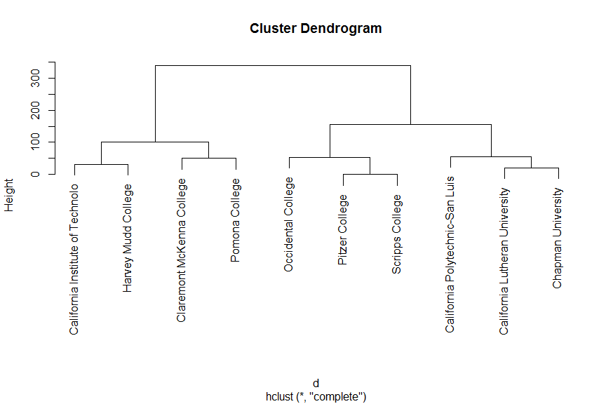

## Dendrogram

- Tree diagram that shows how close (or not) cases are to one another
- leaf: single case
- fusing leaves: as we go up a tree we fuse cases connected by a common branch
  - fusing leaves creates a cluster of the cases involved in the fuse
- y-axis height: How *dissimilar* cases are
  - low height: similar
  - high height: dissimilar

## Simple example:

- here are \(9\) data points with `two` variables
- How do we create a `dendogram` from these points?

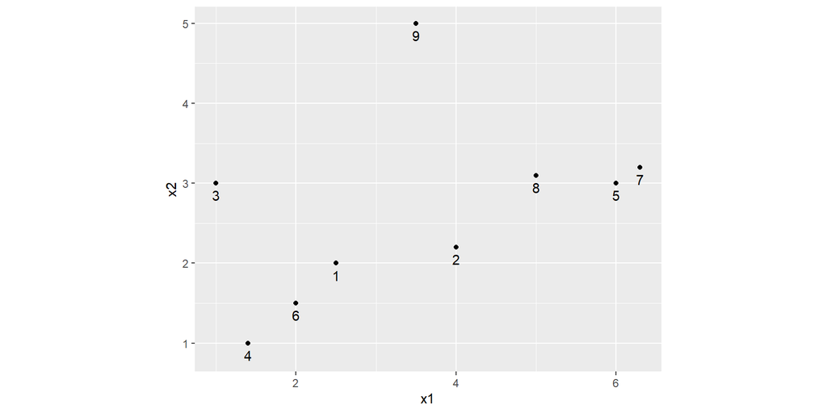

## Algorithm

- pick a dissimilarity measure
  - here: Euclidean distance (standardize if needed!)
1. start at the bottom: n cases are the n clusters.
   - measure all dissimilarities (distance) between clusters (cases)
2. Fuse the two clusters that are least dissimilar (closest)
   - tree height of fuse = dissimilarity measure (distance apart)
3. For the new set of clusters, measure dissimilarity.
4. Repeat 2-3 until only one cluster exists (top of the tree)

## Algorithm

- Slight problem: After first fuse, we have a cluster with 2 cases in it.
  - how to we measure dissimilarity (distance) between this cluster and all others?
- **Linkage**: options for computing dissimilarity between clusters of cases
  - complete: maximum dissimilarity (distance) between any pair of cases in cluster A and cluster B
  - average: compute average of all dissimilarities (distances) between all pairs of cases in cluster A and B
  - others: median, centroid

## Simple example: starting point

- Start with all points as distinct `leaves`
- Which two `leaves` are the first to be `fused`?

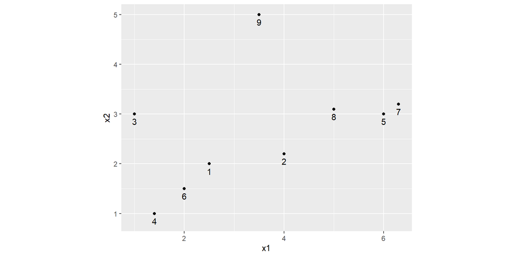

## Simple example: first round

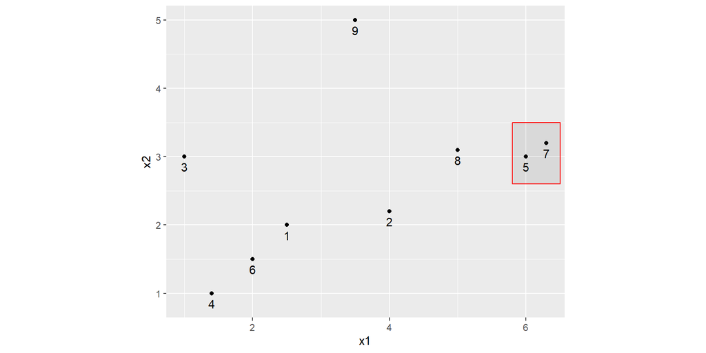

- \(5\) and \(7\) are the closest
- What is the next step?

## Simple example: second round

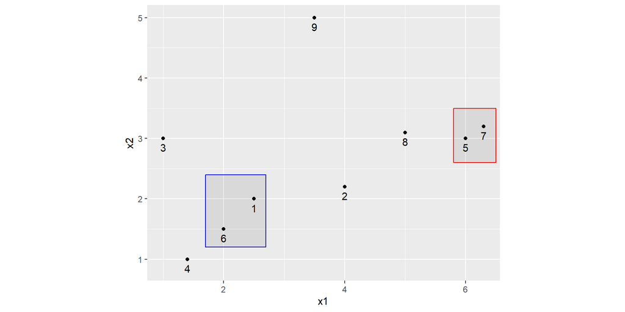

- \(6\) and \(1\) are the next closest
- What is the next step?

## Simple example: third round

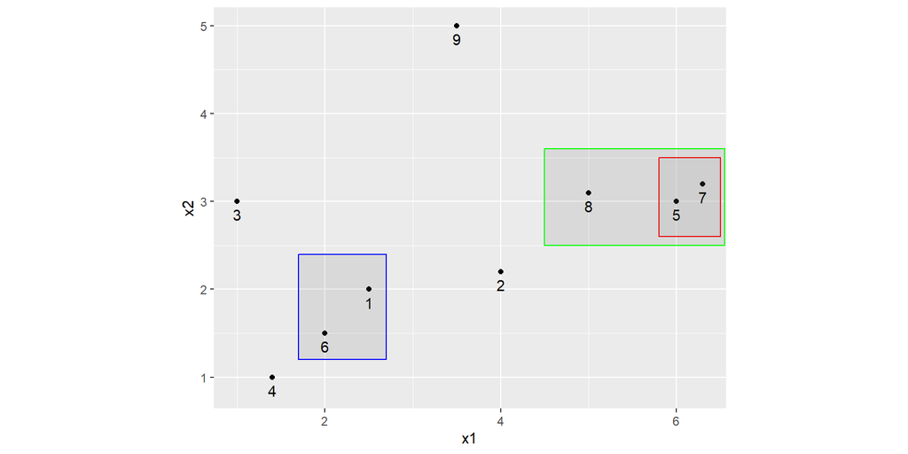

- \(8\) and \(5/7\) are the next closest
- The distance is the \(MAX\) so \(8\) vs \(7\)

## Simple example: Comparing with the tree

- Go back and compare

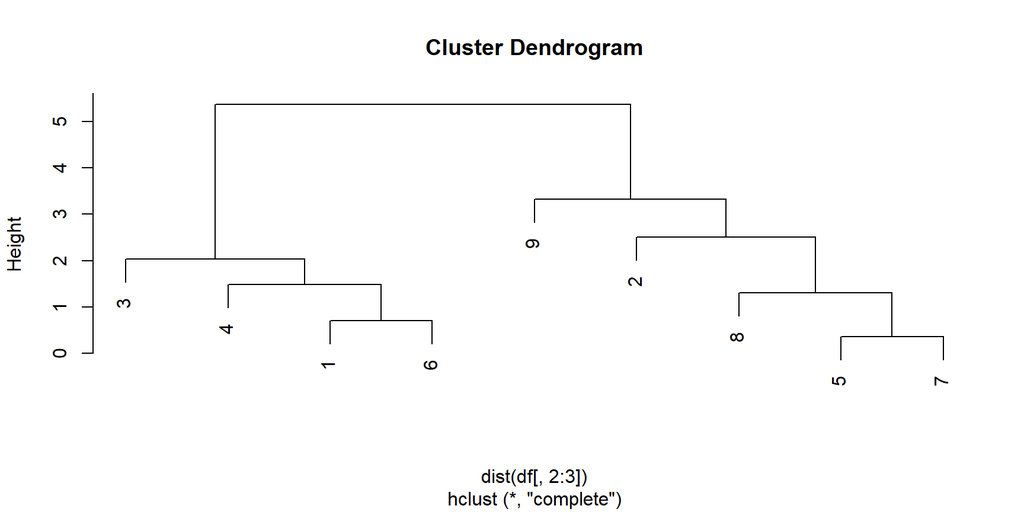

## Simple example:

- cut at 0.5 fuses 5 and 7, they are most similar (or least dissimilar!)

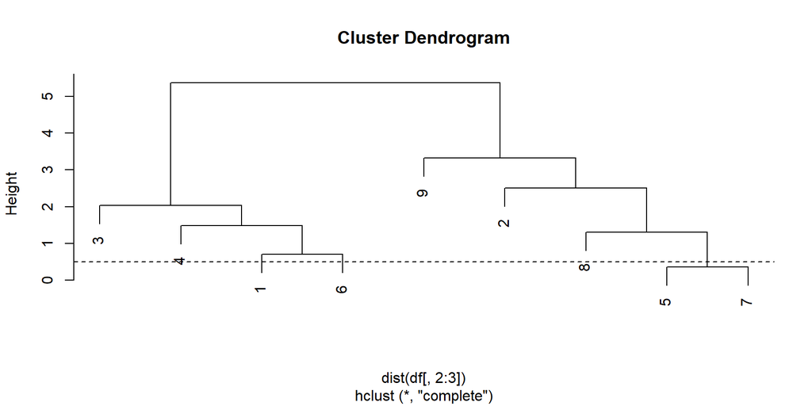

## Simple example:

- cut at 1.5 fuses 5, 7 and 8 and 1,4 and 6.

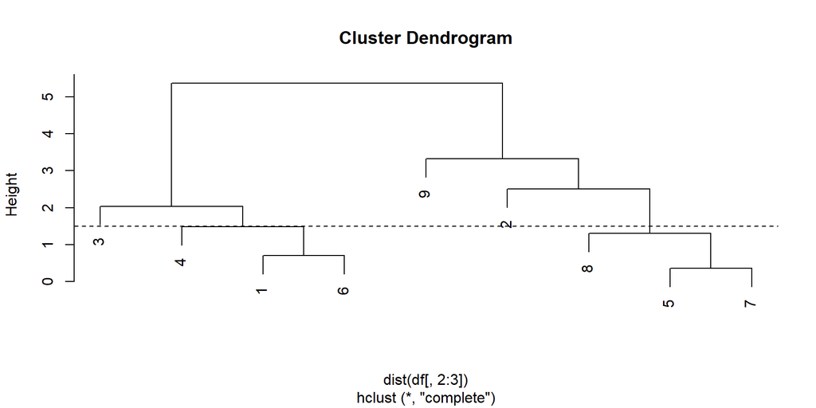

## Simple example:

- Based on dendrogram: Is 9 more similar to 2 or to 5?

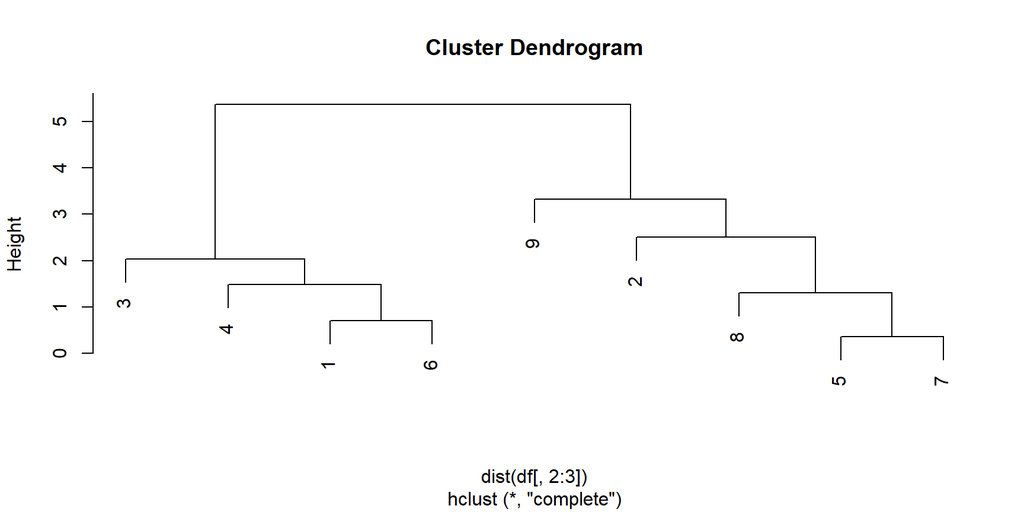

## Simple example:

- Can’t tell: 9 is fused with both 2 and 5 at the *same* height (dissimilarity)
- Can tell: 9 is more similar to 2,5 than it is to 1 (fuse with 1 is higher than fuse with 2,5)

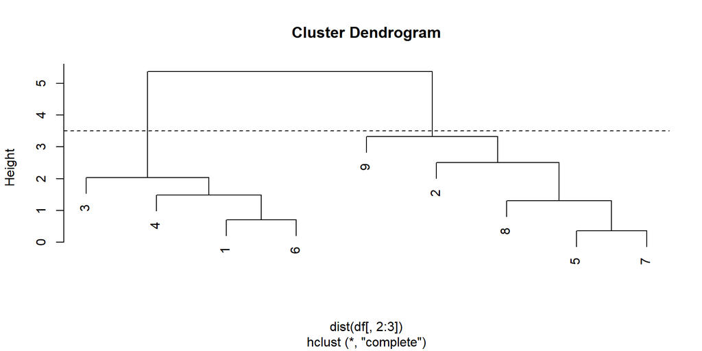

## Hierarchical clustering in R

- use base-R function `hclust`
  - default: Euclidean distance + complete linkage (`method`)
- First compute the distance matrix between variables:

```
d <- dist(Xvars)
```

- then run `hclust` and plot (`Xvars$id` is an identifier of cases)

```
hc_obj <- hclust(d)
plot(hc_obj, labels=Xvars$id)
```

- cut the tree to classify into `k` clusters

```
cutree(hc_obj, k=)
```

## College grouping example

- Let’s cluster together some colleges/universities in CA
- Here is a subset of 10 schools
- Focus on average SATM and SATV scores for freshman class

```
# A tibble: 10 × 3
   College                           SATM  SATV
   <chr>                            <dbl> <dbl>
 1 California Institute of Technolo   750   660
 2 California Lutheran University     495   436
 3 California Polytechnic-San Luis    547   455
 4 Chapman University                 501   456
 5 Claremont McKenna College          670   600
 6 Harvey Mudd College                740   630
 7 Pitzer College                     590   560
 8 Pomona College                     700   640
 9 Scripps College                    590   560
10 Occidental College                 570   510
```

## College grouping example

- Which schools are most similar?
- How would you group them?

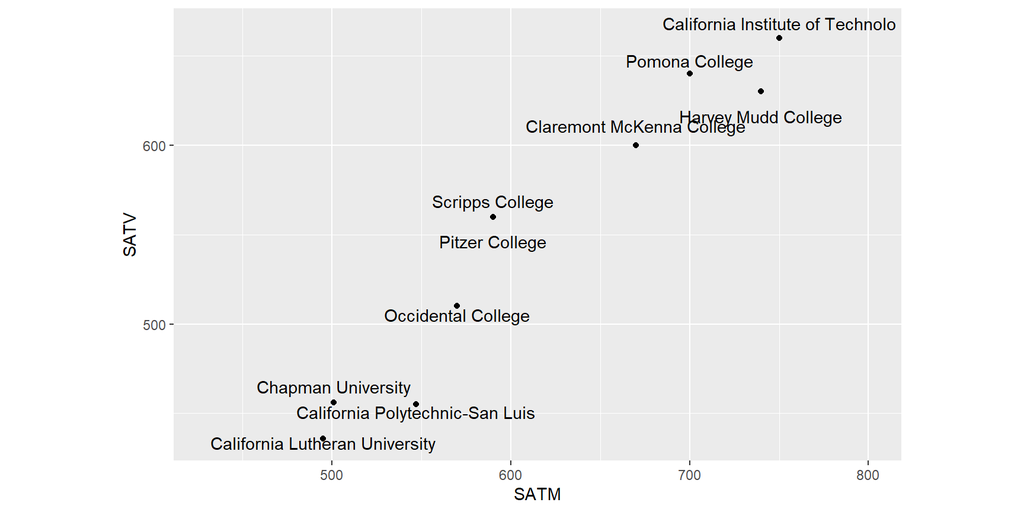

## College grouping example

- Compute the distance between SAT scores for all 45 pairs of schools

```r
> choose(10,2)
[1] 45
> d <- dist(colleges.CA[,c("SATM","SATV")])
```

- Note that we did not `scale` the variables because they are similar in size/range!
- Then use these distances to get hierarchical clustering:

```r
> CA_hc <- hclust(d)
```

## College grouping example

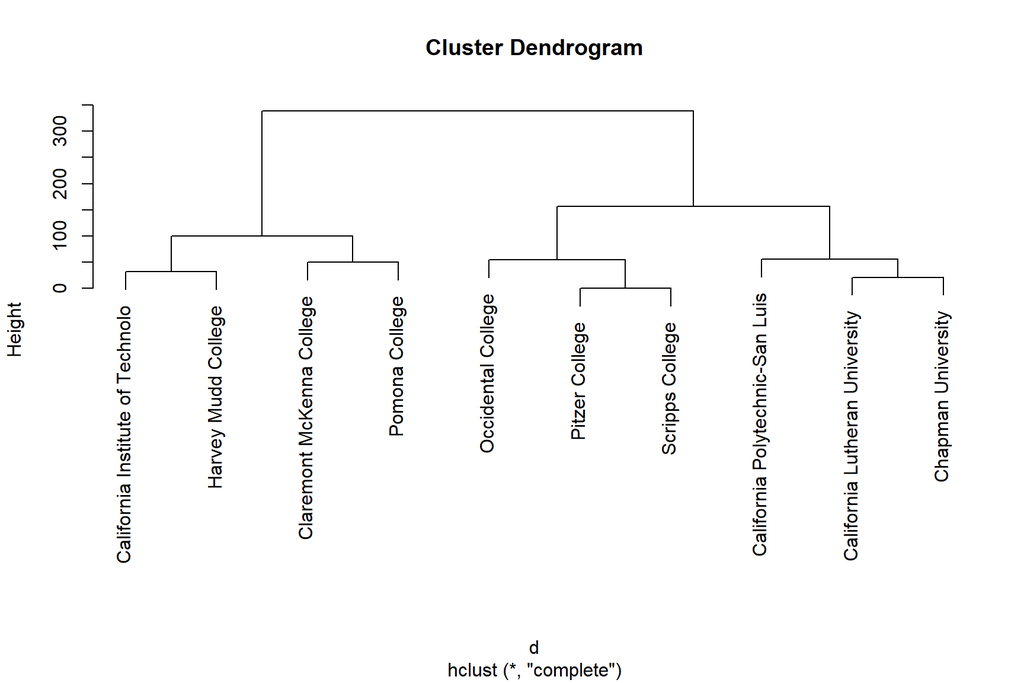

```r
> plot(CA_hc, labels=colleges.CA$College)
```

## College grouping example

- We can cut the tree to get 3 clusters. Here we ask specifically for 3 clusters:

```r
> cutree(CA_hc, k=3)
 [1] 1 2 2 2 1 1 3 1 3 3
```

- Add these classifications to the data frame.

```r
> colleges.CA <- colleges.CA %>%
+   mutate(clusters3 = as.character(cutree(CA_hc, k=3)))
```

- Now plot:

```r
> set.seed(7)
> ggplot(colleges.CA, aes(SATM,SATV,color=clusters3)) +
+   geom_point() +
+   geom_text(aes(label=College), position=position_jitter(width=0,height=15)) +
+   coord_fixed(xlim = c(430, 800),ylim=c(440,665))
```

## College grouping example

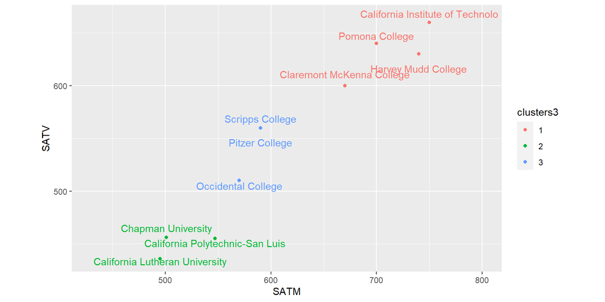

## College grouping example

- What if we cut the tree at a height of 60. How many clusters?

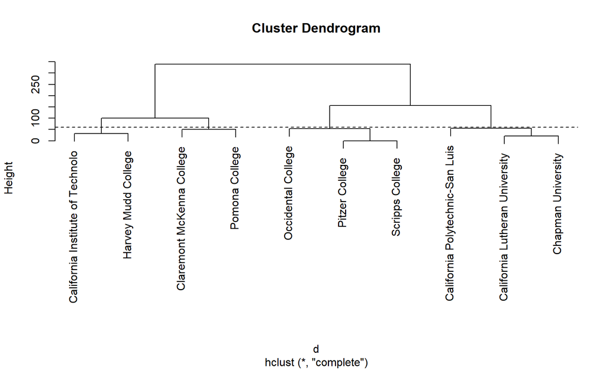

```r
> plot(CA_hc, labels=colleges.CA$College); abline(h=60, lty=2)
```

## College grouping example

- We can cut the tree at a specific height:

```r
> cutree(CA_hc, h=60)
 [1] 1 2 2 2 3 1 4 3 4 4
```

- Now we have 4 clusters. Add these classifications to the data frame

```r
> colleges.CA <- colleges.CA %>%
+   mutate(clusters4 = as.character(cutree(CA_hc, h=70)))
```

- Now plot:

```r
> ggplot(colleges.CA, aes(SATM,SATV,color=clusters4)) +
+   geom_point() +
+   geom_text(aes(label=College), nudge_y = 10)
```

## College grouping example

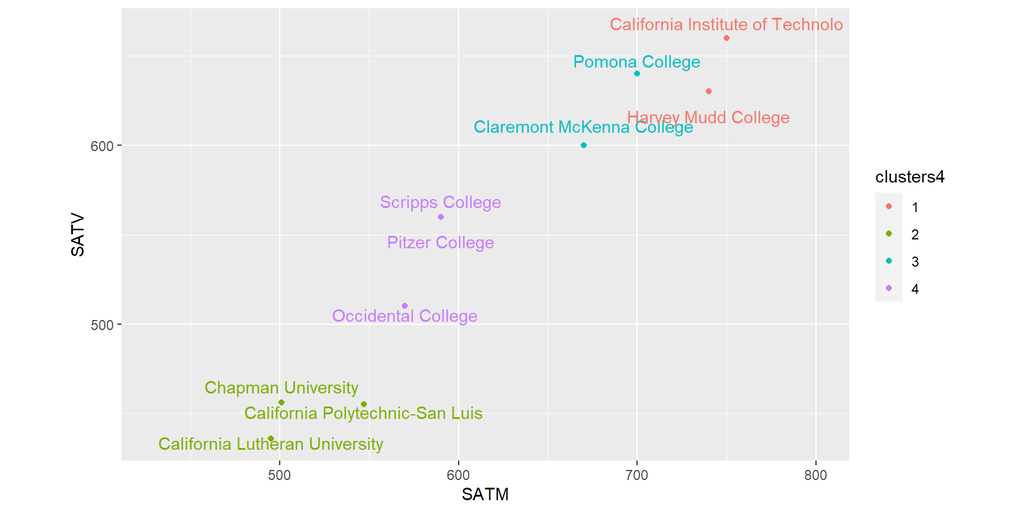

## Differences with k-means

- Advantages of `heiarchical` vs `kmeans`
  - Provides a nice visualization of the data
  - No requirement to choose `k` ahead of time
  - Can customize the algorithm by choosing different ways to calculate distance between leafs
- Advantages of `kmeans` vs `heiarchical`
  - If you have a large dataset, `kmeans` is faster
  - `kmeans` allows you to easily quantify (using `withinss`) the tradeoff of adding more clusters